# Bellabeat Case Study

Laith

8/31/2021

[figure not shown]

# Mission Statement / Introduction

The purpose of this report is to aid Bellabeat in marketing to its customer base as a member if its marketing analytics team. The trends identified from the FitBit data will be identified and compared to the range of products and services offered by Bellabeat. The insights gathered will be used to alter the marketing strategy on a high level as they are both smart devices.

## I.Ask

### Questions to be Answered

- What are some trends in smart device usage?
- How could these trends apply to Bellabeat customers?
- How could these trends help influence Bellabeat marketing strategy?

### Shareholders of this analysis

- Urška Sršen - Bellabeat CEO & Cofounder
- Sando Mur - Cofounder and Mathematician
- Marketing Analytics Team at Bellabeat

## II.Prepare

### Installing and Loading Packages

[output not shown]

[output not shown]

[output not shown]

[output not shown]

[output not shown]

[output not shown]

[output not shown]

```
## here() starts at C:/Users/laith/Desktop
```

### Importing Datasets

The data frames will be merged and analyzed based off of the time frame that the data is recorded.

```r
#daily files to be merged
activity <- read.csv("./Fitabase Data 4.12.16-5.12.16/dailyActivity_merged.csv")
calories <- read.csv("./Fitabase Data 4.12.16-5.12.16/dailyCalories_merged.csv")
intensities <- read.csv("./Fitabase Data 4.12.16-5.12.16/dailyIntensities_merged.csv")
steps <- read.csv("./Fitabase Data 4.12.16-5.12.16/dailySteps_merged.csv")
weight_log <- read.csv("./Fitabase Data 4.12.16-5.12.16/weightLogInfo_merged.csv")
sleep_Day <- read.csv("./Fitabase Data 4.12.16-5.12.16/sleepDay_merged.csv")

#minute files to be merged together
minute_MET <-read.csv("./Fitabase Data 4.12.16-5.12.16/minuteMETsNarrow_merged.csv")
heart_rate_Sec <- read.csv("./Fitabase Data 4.12.16-5.12.16/heartrate_seconds_merged.csv")
sleep_min <- read.csv("./Fitabase Data 4.12.16-5.12.16/minuteSleep_merged.csv")
step_min <- read.csv("./Fitabase Data 4.12.16-5.12.16/minuteStepsNarrow_merged.csv")
cals_min <- read.csv("./Fitabase Data 4.12.16-5.12.16/minuteCaloriesNarrow_merged.csv")
intensities_min <- read.csv("./Fitabase Data 4.12.16-5.12.16/minuteIntensitiesNarrow_merged.csv")

#Hourly data sets to be merged together
hourlyIntensities <- read.csv(("./Fitabase Data 4.12.16-5.12.16/hourlyIntensities_merged.csv"))
hourlyCalories <- read.csv(("./Fitabase Data 4.12.16-5.12.16/hourlyCalories_merged.csv"))
hourlySteps <- read.csv("./Fitabase Data 4.12.16-5.12.16/hourlySteps_merged.csv")
```

### Checking DataFrames for Any Inconsistencies

```r
str(activity)
```

```
## 'data.frame':    940 obs. of  15 variables:
##  $ Id                      : num  1.5e+09 1.5e+09 1.5e+09 1.5e+09 1.5e+09 ...
##  $ ActivityDate            : chr  "4/12/2016" "4/13/2016" "4/14/2016" "4/15/2016" ...
##  $ TotalSteps              : int  13162 10735 10460 9762 12669 9705 13019 15506 10544 9819 ...
##  $ TotalDistance           : num  8.5 6.97 6.74 6.28 8.16 ...
##  $ TrackerDistance         : num  8.5 6.97 6.74 6.28 8.16 ...
##  $ LoggedActivitiesDistance: num  0 0 0 0 0 0 0 0 0 0 ...
##  $ VeryActiveDistance      : num  1.88 1.57 2.44 2.14 2.71 ...
##  $ ModeratelyActiveDistance: num  0.55 0.69 0.4 1.26 0.41 ...
##  $ LightActiveDistance     : num  6.06 4.71 3.91 2.83 5.04 ...
##  $ SedentaryActiveDistance : num  0 0 0 0 0 0 0 0 0 0 ...
##  $ VeryActiveMinutes       : int  25 21 30 29 36 38 42 50 28 19 ...
##  $ FairlyActiveMinutes     : int  13 19 11 34 10 20 16 31 12 8 ...
##  $ LightlyActiveMinutes    : int  328 217 181 209 221 164 233 264 205 211 ...
##  $ SedentaryMinutes        : int  728 776 1218 726 773 539 1149 775 818 838 ...
##  $ Calories                : int  1985 1797 1776 1745 1863 1728 1921 2035 1786 1775 ...
```

```r
str(calories)
```

```
## 'data.frame':    940 obs. of  3 variables:
##  $ Id         : num  1.5e+09 1.5e+09 1.5e+09 1.5e+09 1.5e+09 ...
##  $ ActivityDay: chr  "4/12/2016" "4/13/2016" "4/14/2016" "4/15/2016" ...
##  $ Calories   : int  1985 1797 1776 1745 1863 1728 1921 2035 1786 1775 ...
```

```r
str(intensities)
```

```
## 'data.frame':    940 obs. of  10 variables:
##  $ Id                      : num  1.5e+09 1.5e+09 1.5e+09 1.5e+09 1.5e+09 ...
##  $ ActivityDay             : chr  "4/12/2016" "4/13/2016" "4/14/2016" "4/15/2016" ...
##  $ SedentaryMinutes        : int  728 776 1218 726 773 539 1149 775 818 838 ...
##  $ LightlyActiveMinutes    : int  328 217 181 209 221 164 233 264 205 211 ...
##  $ FairlyActiveMinutes     : int  13 19 11 34 10 20 16 31 12 8 ...
##  $ VeryActiveMinutes       : int  25 21 30 29 36 38 42 50 28 19 ...
##  $ SedentaryActiveDistance : num  0 0 0 0 0 0 0 0 0 0 ...
##  $ LightActiveDistance     : num  6.06 4.71 3.91 2.83 5.04 ...
##  $ ModeratelyActiveDistance: num  0.55 0.69 0.4 1.26 0.41 ...
##  $ VeryActiveDistance      : num  1.88 1.57 2.44 2.14 2.71 ...
```

```r
str(steps)
```

```
## 'data.frame':    940 obs. of  3 variables:
##  $ Id         : num  1.5e+09 1.5e+09 1.5e+09 1.5e+09 1.5e+09 ...
##  $ ActivityDay: chr  "4/12/2016" "4/13/2016" "4/14/2016" "4/15/2016" ...
##  $ StepTotal  : int  13162 10735 10460 9762 12669 9705 13019 15506 10544 9819 ...
```

```r
str(weight_log)
```

```
## 'data.frame':    67 obs. of  8 variables:
##  $ Id            : num  1.50e+09 1.50e+09 1.93e+09 2.87e+09 2.87e+09 ...
##  $ Date          : chr  "5/2/2016 11:59:59 PM" "5/3/2016 11:59:59 PM" "4/13/2016 1:08:52 AM" "4/21/2016 11:59:59 PM" ...
##  $ WeightKg      : num  52.6 52.6 133.5 56.7 57.3 ...
##  $ WeightPounds  : num  116 116 294 125 126 ...
##  $ Fat           : int  22 NA NA NA NA 25 NA NA NA NA ...
##  $ BMI           : num  22.6 22.6 47.5 21.5 21.7 ...
##  $ IsManualReport: chr  "True" "True" "False" "True" ...
##  $ LogId         : num  1.46e+12 1.46e+12 1.46e+12 1.46e+12 1.46e+12 ...
```

## III.Process

#### Cleaning Data -Formatting Date

It was observed that the Date attribute for the all the data frames imported was in the “Chr” data type. We would need to convert to **date time** data type. The lubridate library was utilized for this and done for each of the daily data frames as those are the main data frames being utilized for this analysis.

```r
library(lubridate)
#activity
activity$ActivityDate= as.POSIXct(activity$ActivityDate, format= "%m/%d/%Y", tz=Sys.timezone())
activity$date <- format(activity$ActivityDate, format="%m/%d/%y")
#steps
steps$ActivityDay = as.POSIXct(steps$ActivityDay, format = "%m/%d/%Y", tz= Sys.timezone())
steps$date <- format(steps$ActivityDay, format = "%m/%d/%y")
#intensities
intensities$ActivityDay = as.POSIXct(intensities$ActivityDay, format = "%m/%d/%Y", tz=Sys.timezone())
intensities$date <- format(intensities$ActivityDay, format = "%m/%d/%y")
#calories
calories$ActivityDay = as.POSIXct(calories$ActivityDay, format = "%m/%d/%Y", tz=Sys.timezone())
calories$date <- format(calories$ActivityDay, format = "%m/%d/%y")
#minute_MET
minute_MET$ActivityMinute = as.POSIXct(minute_MET$ActivityMinute, format="%m/%d/%Y %I:%M:%S %p", tz=Sys.timezone())
minute_MET$time <- format(minute_MET$ActivityMinute, format="%H:%M:%S")
minute_MET$date <- format(minute_MET$ActivityMinute, format="%m/%d/%y")
#weight_log
weight_log$Date = as.POSIXct(weight_log$Date, format="%m/%d/%Y %I:%M:%S %p", tz=Sys.timezone())
weight_log$time <- format(weight_log$Date, format="%H:%M:%S")
weight_log$date <- format(weight_log$Date, format="%m/%d/%y")
#sleep_Day
sleep_Day$SleepDay = as.POSIXct(sleep_Day$SleepDay, format = "%m/%d/%Y %I:%M:%S %p", tz=Sys.timezone())
sleep_Day$date <-format(sleep_Day$SleepDay, format="%m/%d/%y")
#hourlyCalories

hourlyCalories$ActivityHour = as.POSIXct(hourlyCalories$ActivityHour, format ="%m/%d/%Y %I:%M:%S %p", tz = Sys.timezone())
hourlyCalories$time <- format(hourlyCalories$ActivityHour, format="%H:%M:%S")
hourlyCalories$date <- format(hourlyCalories$ActivityHour, format = "%m/%d/%y")
#hourlyIntensities
hourlyIntensities$ActivityHour = as.POSIXct(hourlyIntensities$ActivityHour, format="%m/%d/%Y %I:%M:%S %p", tz = Sys.timezone())
hourlyIntensities$time <- format(hourlyIntensities$ActivityHour, format="H:%M:%S")
hourlyIntensities$date <- format(hourlyIntensities$ActivityHour, format = "%m/%d/%y")
#heartrate seconds
heart_rate_Sec$Time = as.POSIXct(heart_rate_Sec$Time, format = "%m/%d/%Y %I:%M:%S %p", tz= Sys.timezone())
heart_rate_Sec$time <- format(heart_rate_Sec$Time, format = "%H:%M:%S")
heart_rate_Sec$date <- format(heart_rate_Sec$Time, format = "%m/%d/%y")
```

#### Cleaning Data - Duplicate Removal

We will be using the distinct function from the **dplyr** package in order to ensure that there are no duplicates based of the ID and Date columns per row.

```r
install.packages("dplyr")
library(dplyr)
#activity duplicate check
activity %>%
  distinct(Id, ActivityDate, .keep_all = TRUE)
```

[output not shown]

[output cut: 3749 more lines]

```r
# no duplicates found
# calories duplicate check
calories %>%
  distinct(Id, ActivityDay, .keep_all = TRUE)
```

[output not shown]

[output cut: 926 more lines]

```r
#no duplicates found
#sleepday check
sleep_Day %>%
  distinct(Id, SleepDay, .keep_all = TRUE)
```

[output not shown]

[output cut: 807 more lines]

```r
# 3 duplicate rows were found and removed
#Re-assinging cleaned Dataframe to sleep_Day
sleep_Day <- sleep_Day %>% distinct(Id, SleepDay, .keep_all = TRUE)
#weight_log
weight_log %>%
  distinct(Id,Date, .keep_all = TRUE)
```

[output not shown]

[output cut: 121 more lines]

```r
#No duplicates found
```

### Initial Data Exploration

```r
n_distinct(activity$Id)
```

```
## [1] 33
```

```r
n_distinct(calories$Id)
```

```
## [1] 33
```

```r
n_distinct(intensities$Id)
```

```
## [1] 33
```

```r
n_distinct(sleep_Day$Id)
```

```
## [1] 24
```

```r
n_distinct(weight_log$Id)
```

```
## [1] 8
```

Initial observations from this exploration:

- 33 participants were included in the data as opposed to the initially estimated 30.
- The **activity**, **calories**, and the **intensities** csv files all have 33 distinct user id’s. This would cause for an investigation of inclusion in order to aid in the consolidation of the files to a single data frame that will be utilized in trend identification and visualization later on in the analysis. *Only 8 partcipants participated in the logging of their weight this would need to be taken into account.

### Narrowing Down Daily Data Frames to be Analyzed Using “sqldf”

The values from **calories**, **intensities** and **steps** data frames are believed to be contained in the activity data frame. The **sqldf** package is loaded to confirm this. A temporary data frame with the relevant columns is created from the **activity** data frames and compared to the various data frames with the utilization of an “INTERSECT SELECT”. The head function is used to compare the values from the two temporary data frames. The code written to do this is highlighted below:

```r
install.packages("sqldf", repos = "http://cran.us.r-project.org")
library("sqldf")
daily_activity2 <- activity %>%
  select(Id, ActivityDate, Calories, date)
head(daily_activity2)
```

```
##           Id ActivityDate Calories     date
## 1 1503960366   2016-04-12     1985 04/12/16
## 2 1503960366   2016-04-13     1797 04/13/16
## 3 1503960366   2016-04-14     1776 04/14/16
## 4 1503960366   2016-04-15     1745 04/15/16
## 5 1503960366   2016-04-16     1863 04/16/16
## 6 1503960366   2016-04-17     1728 04/17/16
```

```r
sql_check1 <- sqldf('SELECT * FROM daily_activity2 INTERSECT SELECT * FROM calories')
head(sql_check1)
```

```
##           Id ActivityDate Calories     date
## 1 1503960366   2016-04-12     1985 04/12/16
## 2 1503960366   2016-04-13     1797 04/13/16
## 3 1503960366   2016-04-14     1776 04/14/16
## 4 1503960366   2016-04-15     1745 04/15/16
## 5 1503960366   2016-04-16     1863 04/16/16
## 6 1503960366   2016-04-17     1728 04/17/16
```

```r
nrow(sql_check1)
```

```
## [1] 940
```

```r
# result from the temporary data fram corresponds to the calories data frame.
```

```r
daily_activity3 <- activity %>%
  select(Id, ActivityDate, SedentaryMinutes, LightlyActiveMinutes, FairlyActiveMinutes, VeryActiveMinutes, SedentaryActiveDistance, LightActiveDistance , ModeratelyActiveDistance, VeryActiveDistance, date)
head(daily_activity3)
```

```
##           Id ActivityDate SedentaryMinutes LightlyActiveMinutes
## 1 1503960366   2016-04-12              728                  328
## 2 1503960366   2016-04-13              776                  217
## 3 1503960366   2016-04-14             1218                  181
## 4 1503960366   2016-04-15              726                  209
## 5 1503960366   2016-04-16              773                  221
## 6 1503960366   2016-04-17              539                  164
##   FairlyActiveMinutes VeryActiveMinutes SedentaryActiveDistance
## 1                  13                25                       0
## 2                  19                21                       0
## 3                  11                30                       0
## 4                  34                29                       0
## 5                  10                36                       0
## 6                  20                38                       0
##   LightActiveDistance ModeratelyActiveDistance VeryActiveDistance     date
## 1                6.06                     0.55               1.88 04/12/16
## 2                4.71                     0.69               1.57 04/13/16
## 3                3.91                     0.40               2.44 04/14/16
## 4                2.83                     1.26               2.14 04/15/16
## 5                5.04                     0.41               2.71 04/16/16
## 6                2.51                     0.78               3.19 04/17/16
```

```r
sql_check2 <- sqldf('SELECT * FROM daily_activity3 INTERSECT SELECT * FROM intensities')
head(sql_check2)
```

```
##           Id ActivityDate SedentaryMinutes LightlyActiveMinutes
## 1 1503960366   2016-04-12              728                  328
## 2 1503960366   2016-04-13              776                  217
## 3 1503960366   2016-04-14             1218                  181
## 4 1503960366   2016-04-15              726                  209
## 5 1503960366   2016-04-16              773                  221
## 6 1503960366   2016-04-17              539                  164
##   FairlyActiveMinutes VeryActiveMinutes SedentaryActiveDistance
## 1                  13                25                       0
## 2                  19                21                       0
## 3                  11                30                       0
## 4                  34                29                       0
## 5                  10                36                       0
## 6                  20                38                       0
##   LightActiveDistance ModeratelyActiveDistance VeryActiveDistance     date
## 1                6.06                     0.55               1.88 04/12/16
## 2                4.71                     0.69               1.57 04/13/16
## 3                3.91                     0.40               2.44 04/14/16
## 4                2.83                     1.26               2.14 04/15/16
## 5                5.04                     0.41               2.71 04/16/16
## 6                2.51                     0.78               3.19 04/17/16
```

```r
#results from the temporary data fram and intensities columns match up.
```

```r
daily_activity4 <- activity %>%
  select(Id, ActivityDate, TotalSteps, date )
head(daily_activity4)
```

```
##           Id ActivityDate TotalSteps     date
## 1 1503960366   2016-04-12      13162 04/12/16
## 2 1503960366   2016-04-13      10735 04/13/16
## 3 1503960366   2016-04-14      10460 04/14/16
## 4 1503960366   2016-04-15       9762 04/15/16
## 5 1503960366   2016-04-16      12669 04/16/16
## 6 1503960366   2016-04-17       9705 04/17/16
```

```r
sql_check3 <- sqldf('SELECT * FROM daily_activity4 INTERSECT SELECT * FROM steps')
head(sql_check3)
```

```
##           Id ActivityDate TotalSteps     date
## 1 1503960366   2016-04-12      13162 04/12/16
## 2 1503960366   2016-04-13      10735 04/13/16
## 3 1503960366   2016-04-14      10460 04/14/16
## 4 1503960366   2016-04-15       9762 04/15/16
## 5 1503960366   2016-04-16      12669 04/16/16
## 6 1503960366   2016-04-17       9705 04/17/16
```

Each of the sQL check data frames matches up with the test data frames pulled from the **activity** data frame. Out of the 6 daily csv files loaded for analysis 3 files remain. The **activity** data frame will be the main file being utilized in this analysis. The file is missing Sleeping and Weight information which is found in the **sleep_Day** and the **weight_log** data frames , respectively. The next step would be to merged the three data frames based on the ID and data fields. An additional column of total daily active minutes is created utilizing the **mutate** function this is done below:

```r
activity_ii <- merge(activity, sleep_Day, by =c('Id','date')) %>%
  select(-date,-SleepDay, -TrackerDistance) %>% drop_na() %>%
  rowwise() %>%
  mutate(total_daily_mins = sum(c(LightlyActiveMinutes,FairlyActiveMinutes, VeryActiveMinutes)))
head(activity_ii)
```

```
## # A tibble: 6 x 18
## # Rowwise:
##           Id ActivityDate        TotalSteps TotalDistance LoggedActivitiesDista~
##        <dbl> <dttm>                   <int>         <dbl>                  <dbl>
## 1 1503960366 2016-04-12 00:00:00      13162          8.5                       0
## 2 1503960366 2016-04-13 00:00:00      10735          6.97                      0
## 3 1503960366 2016-04-15 00:00:00       9762          6.28                      0
## 4 1503960366 2016-04-16 00:00:00      12669          8.16                      0
## 5 1503960366 2016-04-17 00:00:00       9705          6.48                      0
## 6 1503960366 2016-04-19 00:00:00      15506          9.88                      0
## # ... with 13 more variables: VeryActiveDistance <dbl>,
## #   ModeratelyActiveDistance <dbl>, LightActiveDistance <dbl>,
## #   SedentaryActiveDistance <dbl>, VeryActiveMinutes <int>,
## #   FairlyActiveMinutes <int>, LightlyActiveMinutes <int>,
## #   SedentaryMinutes <int>, Calories <int>, TotalSleepRecords <int>,
## #   TotalMinutesAsleep <int>, TotalTimeInBed <int>, total_daily_mins <int>
```

The only remaining data frame from the daily files is the **weight_log** information.

```r
activity_merged <- merge(activity_ii, weight_log, by = "Id")


head(activity_merged)
```

```
##           Id ActivityDate TotalSteps TotalDistance LoggedActivitiesDistance
## 1 1503960366   2016-05-07      11992          7.71                        0
## 2 1503960366   2016-05-07      11992          7.71                        0
## 3 1503960366   2016-04-25      15355          9.80                        0
## 4 1503960366   2016-04-25      15355          9.80                        0
## 5 1503960366   2016-05-08      10060          6.58                        0
## 6 1503960366   2016-05-08      10060          6.58                        0
##   VeryActiveDistance ModeratelyActiveDistance LightActiveDistance
## 1               2.46                     2.12                3.13
## 2               2.46                     2.12                3.13
## 3               5.29                     0.57                3.94
## 4               5.29                     0.57                3.94
## 5               3.53                     0.32                2.73
## 6               3.53                     0.32                2.73
##   SedentaryActiveDistance VeryActiveMinutes FairlyActiveMinutes
```

[output cut: 27 more lines]

## IV.Analyze

### Basic Calculations Done to Column

The columns for “total_hours_asleep”, “sedentary_hours”, “total_active_hours”, “total_hours_in_bed” were added as counterparts the minute columns.

```r
activity_merged <- activity_merged %>%
  mutate(total_hours_asleep = round(TotalMinutesAsleep/60,1),
         sedentary_hours = round(SedentaryMinutes/60, 1),
         total_active_hours = round(total_daily_mins/60, 1),
         total_hours_in_bed = round(TotalTimeInBed/60, 1)
  )
head(activity_merged)
```

```
##           Id ActivityDate TotalSteps TotalDistance LoggedActivitiesDistance
## 1 1503960366   2016-05-07      11992          7.71                        0
## 2 1503960366   2016-05-07      11992          7.71                        0
## 3 1503960366   2016-04-25      15355          9.80                        0
## 4 1503960366   2016-04-25      15355          9.80                        0
## 5 1503960366   2016-05-08      10060          6.58                        0
## 6 1503960366   2016-05-08      10060          6.58                        0
##   VeryActiveDistance ModeratelyActiveDistance LightActiveDistance
## 1               2.46                     2.12                3.13
## 2               2.46                     2.12                3.13
## 3               5.29                     0.57                3.94
## 4               5.29                     0.57                3.94
## 5               3.53                     0.32                2.73
## 6               3.53                     0.32                2.73
##   SedentaryActiveDistance VeryActiveMinutes FairlyActiveMinutes
```

[output cut: 34 more lines]

### Trend Identification and Aggregation

```r
#activity
activity %>%
  select(TotalSteps, TotalDistance, SedentaryMinutes, LightlyActiveMinutes ,FairlyActiveMinutes,VeryActiveMinutes, Calories) %>%
  summary()
```

```
##    TotalSteps    TotalDistance    SedentaryMinutes LightlyActiveMinutes
##  Min.   :    0   Min.   : 0.000   Min.   :   0.0   Min.   :  0.0
##  1st Qu.: 3790   1st Qu.: 2.620   1st Qu.: 729.8   1st Qu.:127.0
##  Median : 7406   Median : 5.245   Median :1057.5   Median :199.0
##  Mean   : 7638   Mean   : 5.490   Mean   : 991.2   Mean   :192.8
##  3rd Qu.:10727   3rd Qu.: 7.713   3rd Qu.:1229.5   3rd Qu.:264.0
##  Max.   :36019   Max.   :28.030   Max.   :1440.0   Max.   :518.0
##  FairlyActiveMinutes VeryActiveMinutes    Calories
##  Min.   :  0.00      Min.   :  0.00    Min.   :   0
##  1st Qu.:  0.00      1st Qu.:  0.00    1st Qu.:1828
##  Median :  6.00      Median :  4.00    Median :2134
##  Mean   : 13.56      Mean   : 21.16    Mean   :2304
##  3rd Qu.: 19.00      3rd Qu.: 32.00    3rd Qu.:2793
##  Max.   :143.00      Max.   :210.00    Max.   :4900
```

```r
#calories
calories %>%
  select(Calories) %>%
  summary()
```

```
##     Calories
##  Min.   :   0
##  1st Qu.:1828
##  Median :2134
##  Mean   :2304
##  3rd Qu.:2793
##  Max.   :4900
```

```r
#sleep
sleep_Day %>%
  select(TotalSleepRecords, TotalMinutesAsleep, TotalTimeInBed) %>%
  summary()
```

```
##  TotalSleepRecords TotalMinutesAsleep TotalTimeInBed
##  Min.   :1.00      Min.   : 58.0      Min.   : 61.0
##  1st Qu.:1.00      1st Qu.:361.0      1st Qu.:403.8
##  Median :1.00      Median :432.5      Median :463.0
##  Mean   :1.12      Mean   :419.2      Mean   :458.5
##  3rd Qu.:1.00      3rd Qu.:490.0      3rd Qu.:526.0
##  Max.   :3.00      Max.   :796.0      Max.   :961.0
```

```r
#weight
weight_log %>%
  select(WeightKg, BMI) %>%
  summary()
```

```
##     WeightKg           BMI
##  Min.   : 52.60   Min.   :21.45
##  1st Qu.: 61.40   1st Qu.:23.96
##  Median : 62.50   Median :24.39
##  Mean   : 72.04   Mean   :25.19
##  3rd Qu.: 85.05   3rd Qu.:25.56
##  Max.   :133.50   Max.   :47.54
```

**Trends Observed**

The data will be further explored Now that the data is cleaned and formatted accordingly. The next logical step would be to organized the data for visualization.

The two main factors that will determine organization are daily intensity and daily sleep taken. They will be compared to calories burned.

##### Subgrouping and Calculations on “actvity_merged” for Visualization

```r
usertype_data <- activity_merged %>%
  summarise(
    user_type = factor(case_when(
      SedentaryMinutes > mean(SedentaryMinutes) & LightlyActiveMinutes < mean(LightlyActiveMinutes) & FairlyActiveMinutes < mean(FairlyActiveMinutes) & VeryActiveMinutes < mean(VeryActiveMinutes) ~ "Sedentary",
      SedentaryMinutes < mean(SedentaryMinutes) & LightlyActiveMinutes > mean(LightlyActiveMinutes) & FairlyActiveMinutes < mean(FairlyActiveMinutes) & VeryActiveMinutes < mean(VeryActiveMinutes) ~ "Lightly Active",
      SedentaryMinutes < mean(SedentaryMinutes) & LightlyActiveMinutes < mean(LightlyActiveMinutes) & FairlyActiveMinutes > mean(FairlyActiveMinutes) & VeryActiveMinutes < mean(VeryActiveMinutes) ~ "Fairly Active",
      SedentaryMinutes < mean(SedentaryMinutes) & LightlyActiveMinutes < mean(LightlyActiveMinutes) & FairlyActiveMinutes < mean(FairlyActiveMinutes) & VeryActiveMinutes > mean(VeryActiveMinutes) ~ "Very Active",
    ), level=c("Sedentary","Lightly Active", "Fairly Active", "Very Active")), Calories, .group = Id) %>%
  drop_na()
```

## V.Share

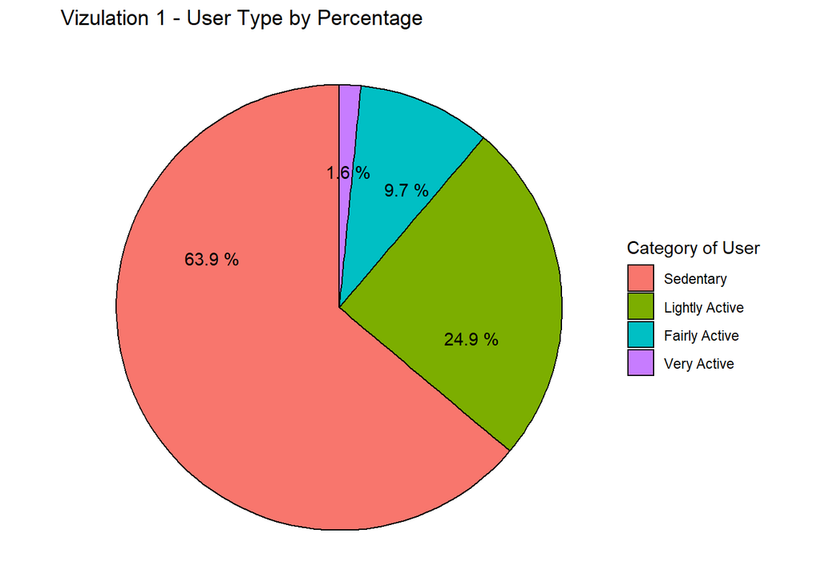

```r
# Next step would be  to visualize the distribution of ser types by a pie chart followed by a box plot for the calories burnt by user type this is done below:
library(ggplot2)
usertype_data %>%
  group_by(user_type) %>%
  summarise(total=n()) %>%
  mutate(totals = sum(total)) %>%
  group_by(user_type) %>%
  summarise(total_percent = total / totals) %>%
  ggplot(aes(user_type, x=" ", y= total_percent, fill = user_type))+ theme_void()+geom_bar(stat='identity', color = 'black')+geom_text(aes(label = paste(round(total_percent * 100, 1), "%"), x = 1.1),
            position = position_stack(vjust = 0.7))+labs(fill = 'Category of User', title = "Vizulation 1 - User Type by Percentage")+coord_polar("y")
```

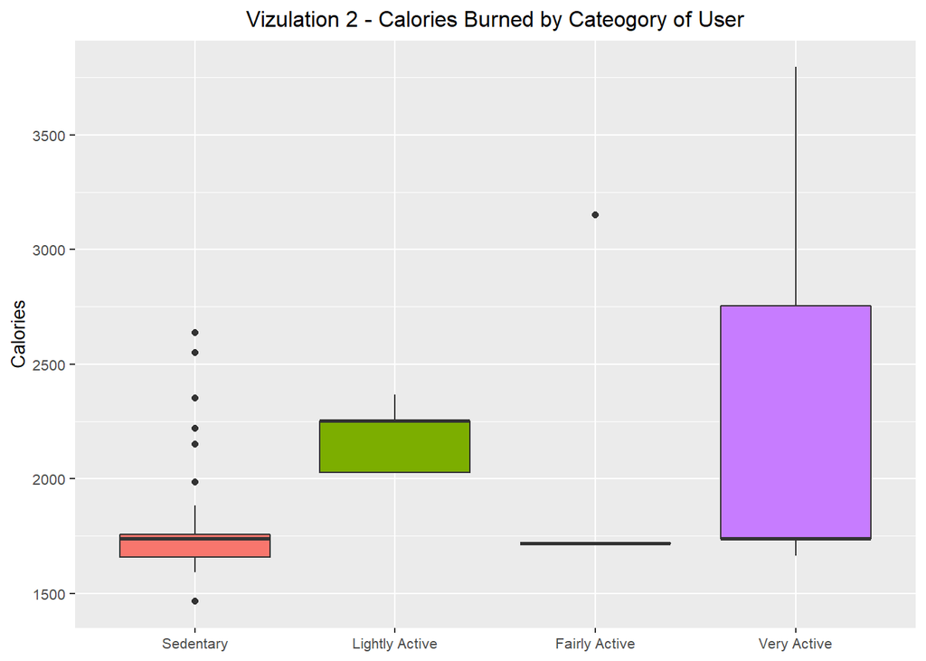

```r
#Box plot of calories burnt per Category of User
ggplot(usertype_data, aes(user_type, Calories, fill=user_type)) + geom_boxplot()+theme(legend.position = "none")+ labs(title="Vizulation 2 - Calories Burned by Cateogory of User", x= NULL) + theme(legend.position = "none", text = element_text(size=10), plot.title = element_text(hjust = 0.5))
```

After getting a breakdown of the user types and the amount of calories burned in the form of a boxplot to gain a general view. The next logical steps was to determine the coefficient of relation between the total steps taken daily and the amount of calories burnt. This is done below:

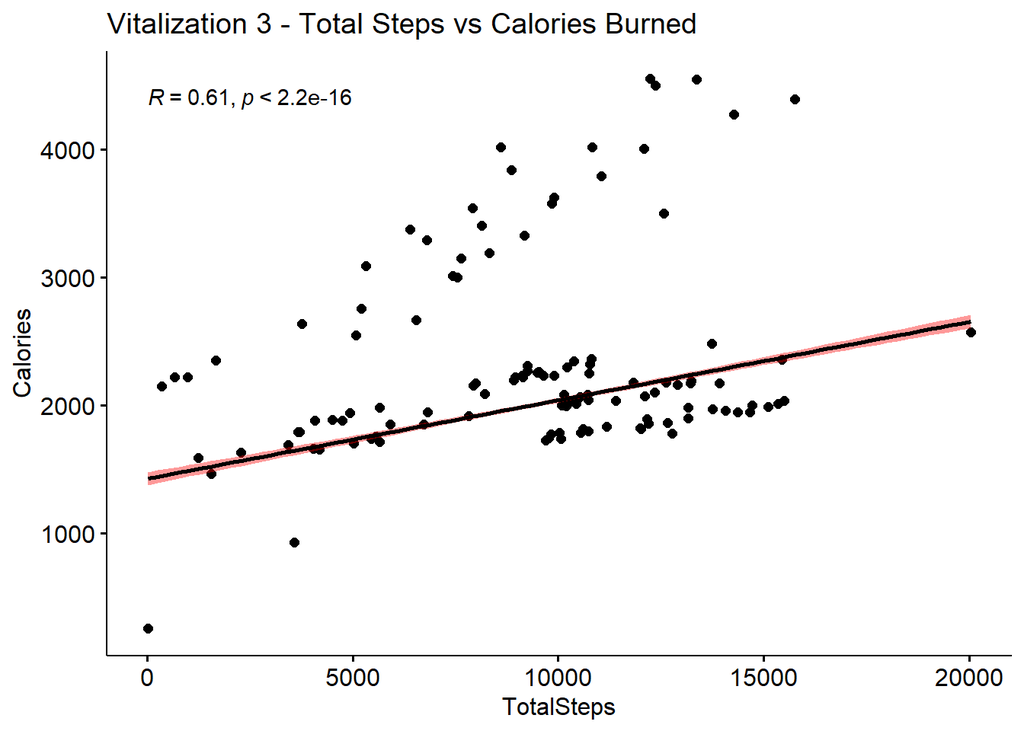

```r
ggscatter(activity_merged,x = "TotalSteps", y="Calories", add ="reg.line", conf.int= TRUE, cor.coef = TRUE, cor.method = "pearson", add.params = list(color = "black", fill ="red"), title = "Vitalization 3 - Total Steps vs Calories Burned")
```

```r
#ggplot(activity, aes(TotalSteps, Calories))+geom_point()+geom_smooth()+labs(title="Vitalization 3 - Total steps and Calories Burned")
```

Visualization 4 - Relationship between the total minutes spent asleep as oppose to time spent in bed.

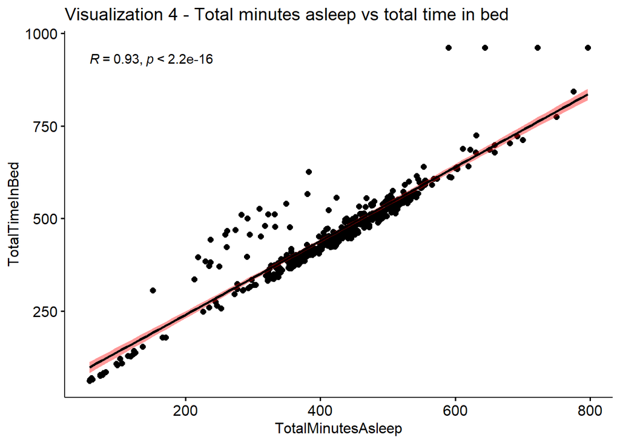

```r
ggscatter(sleep_Day,x = "TotalMinutesAsleep", y="TotalTimeInBed", add ="reg.line", conf.int= TRUE, cor.coef = TRUE, cor.method = "pearson", add.params = list(color = "black", fill ="red"), title = "Visualization 4 - Total minutes asleep vs total time in bed")
```

```r
#ggplot(sleep_Day, aes(TotalMinutesAsleep, TotalTimeInBed))+geom_point()+geom_smooth()+labs(title="Visualization 4 - Total minutes asleep vs total time in bed")
```

Visualization 5 - Relationship between the total steps taken and the total sedentary time

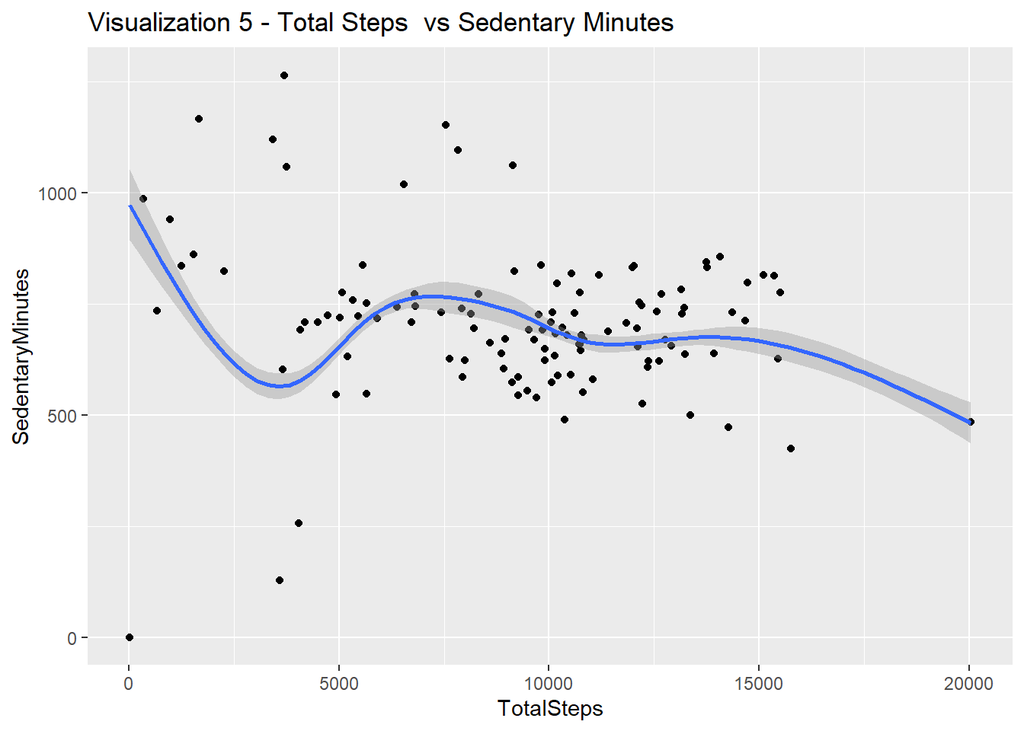

```r
ggplot(activity_merged, aes(TotalSteps, SedentaryMinutes))+geom_point()+geom_smooth()+labs(title="Visualization 5 - Total Steps  vs Sedentary Minutes")
```

Visualization 6 - Relationship between time spent sleeping and sedentary minutes.

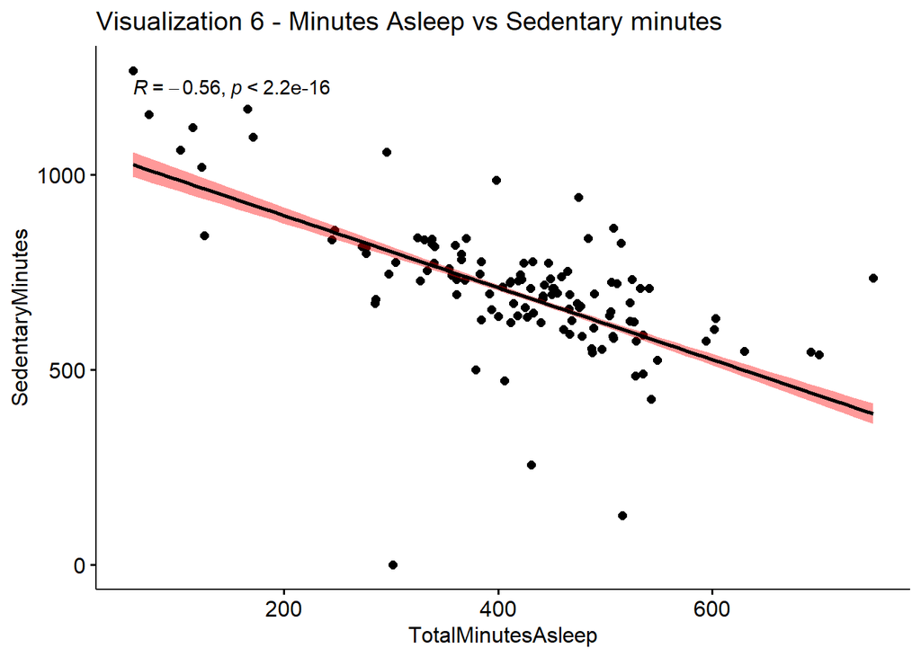

```r
ggscatter(activity_merged,x = "TotalMinutesAsleep", y="SedentaryMinutes", add ="reg.line", conf.int= TRUE, cor.coef = TRUE, cor.method = "pearson", add.params = list(color = "black", fill ="red"), title = "Visualization 6 - Minutes Asleep vs Sedentary minutes")
```